# Project 5: Canonical Correlation Analysis

DA 410

Marjorie Blanco

```r
library(readr)
library(knitr)
library(kableExtra)
library(CCA)
require(GGally)
library(CCA)
library(yacca)
options(scipen=999)
```

Use R to solve Chapter 11 Page 402: #11.9

Make sure you include the commands and outputs, as well as the interpretations of the outputs.

1. Find the canonical correlations between ($y_1$, $y_2$) and ($x_1$, $x_2$).

```r
sons <- as.data.frame(read_table("Software-Files/T3_8_SONS.DAT",
                                 col_names = c("First.Son.Head.Length", "First.Son.Head.Breadth",

                                               "Second.Son.Head.Length", "Second.Son.Head.Breadth"),
                                 cols(
                                   First.Son.Head.Length = col_integer(),
                                   First.Son.Head.Breadth = col_integer(),
                                   Second.Son.Head.Length = col_integer(),
                                   Second.Son.Head.Breadth = col_integer())))
```

For this analysis, we are going to investigate the associations between first son measures and second son measures.

We have a data file, sons.dat, with 25 observations on four variables. The first son variables are head length and head breadth. The second son variables are head length and head breadth.

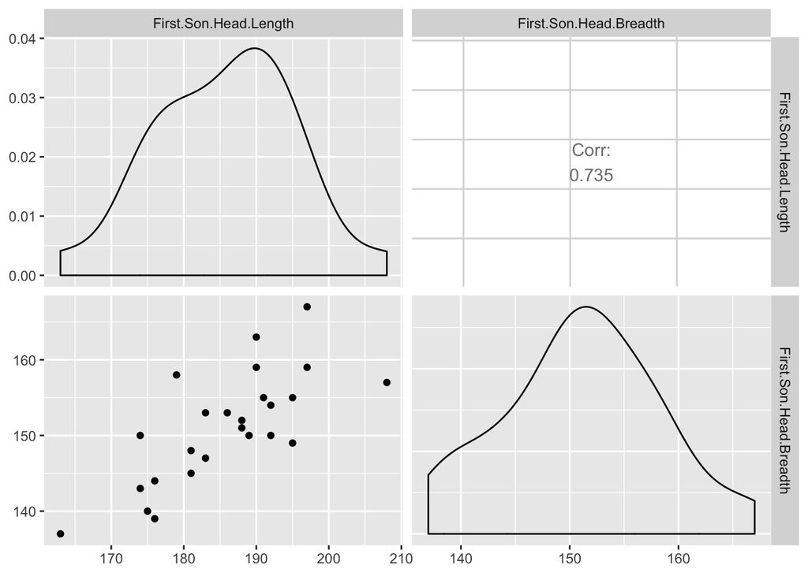

```r
first.son <- sons[, 1:2]
second.son <- sons[, 3:4]

ggpairs(first.son)
```

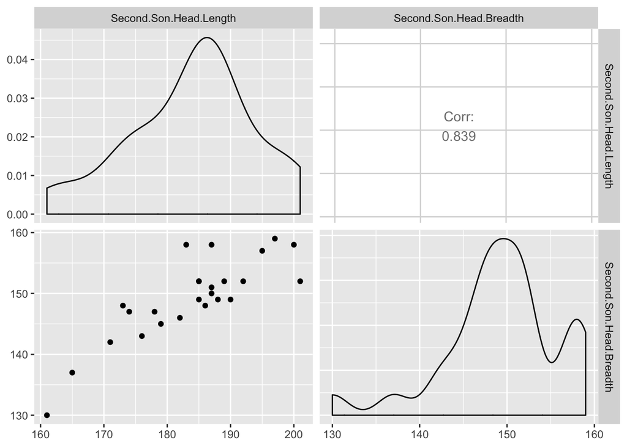

```r
ggpairs(second.son)
```

Correlations

```r
matcor(first.son, second.son)
```

```
## $Xcor
##                        First.Son.Head.Length First.Son.Head.Breadth
## First.Son.Head.Length              1.0000000              0.7345555
## First.Son.Head.Breadth             0.7345555              1.0000000
##
## $Ycor
##                         Second.Son.Head.Length Second.Son.Head.Breadth
## Second.Son.Head.Length               1.0000000               0.8392519
## Second.Son.Head.Breadth              0.8392519               1.0000000
##
## $XYcor
##                         First.Son.Head.Length First.Son.Head.Breadth
## First.Son.Head.Length               1.0000000              0.7345555
## First.Son.Head.Breadth              0.7345555              1.0000000
## Second.Son.Head.Length              0.7107518              0.6931573
## Second.Son.Head.Breadth             0.7039807              0.7085504
##                         Second.Son.Head.Length Second.Son.Head.Breadth
## First.Son.Head.Length                0.7107518               0.7039807
## First.Son.Head.Breadth               0.6931573               0.7085504
## Second.Son.Head.Length               1.0000000               0.8392519
## Second.Son.Head.Breadth              0.8392519               1.0000000
```

Display the canonical correlations

```r
cc1 <- cc(first.son, second.son)
cc1$cor
```

```
## [1] 0.7885079 0.0537397
```

$r_1$ = 0.7885079

$r_2$ = 0.0537397

The first canonical variate captures the most explained variance, canonical r = 0.7885079.

The scree graph of canonical correlations:

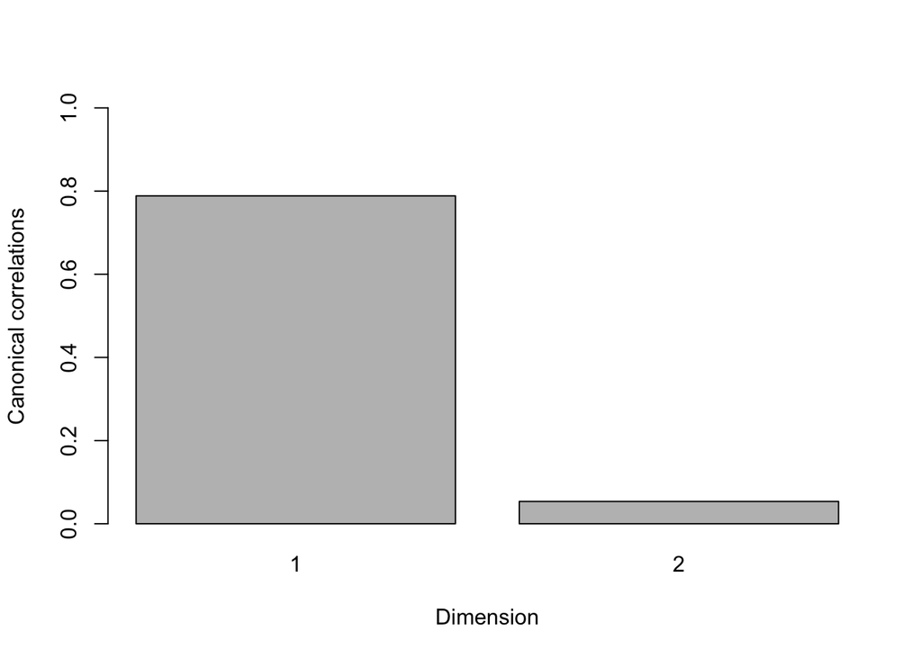

2. Find the standardized coefficients for the canonical variates.

Raw canonical coefficients

```r
cc1[3:4]
```

```
## $xcoef
##                               [,1]       [,2]
## First.Son.Head.Length  -0.05656620 -0.1399711
## First.Son.Head.Breadth -0.07073683  0.1869496
##
## $ycoef
##                               [,1]       [,2]
## Second.Son.Head.Length  -0.0502426 -0.1761479
## Second.Son.Head.Breadth -0.0802224  0.2620836
```

The variable First.Son.Head.Length, a one unit increase leads to a 0.0565662 decrease in the first canonical variate of set 1 when all of the other variables are held constant.

The variable First.Son.Head.Breadth, a one unit increase leads to a 0.0707368 decrease in the first canonical variate of set 1 when all of the other variables are held constant.

The variable First.Son.Head.Length, a one unit increase leads to a 0.1399711 decrease in the second canonical variate of set 1 when all of the other variables are held constant.

The variable First.Son.Head.Breadth, a one unit increase leads to a 0.1869496 increase in the second canonical variate of set 1 when all of the other variables are held constant.

The variable Second.Son.Head.Length, a one unit increase leads to a 0.0502426 decrease in the first canonical variate of set 2 when all of the other variables are held constant.

The variable Second.Son.Head.Breadth, a one unit increase leads to a 0.0802224 decrease in the first canonical variate of set 2 when all of the other variables are held constant.

The variable Second.Son.Head.Length, a one unit increase leads to a 0.1761479 decrease in the second canonical variate of set 2 when all of the other variables are held constant.

The variable Second.Son.Head.Breadth, a one unit increase leads to a 0.2620836 increase in the second canonical variate of set 2 when all of the other variables are held constant.

Compute canonical loadings

```r
cc2 <- comput(first.son, second.son, cc1)
cc2[3:6]
```

```
## $corr.X.xscores
##                              [,1]       [,2]
## First.Son.Head.Length  -0.9352877 -0.3538884
## First.Son.Head.Breadth -0.9271512  0.3746875
##
## $corr.Y.xscores
##                               [,1]        [,2]
## Second.Son.Head.Length  -0.7539771 -0.01572908
## Second.Son.Head.Breadth -0.7582663  0.01474027
##
## $corr.X.yscores
##                              [,1]        [,2]
## First.Son.Head.Length  -0.7374817 -0.01901786
## First.Son.Head.Breadth -0.7310660  0.02013559
##
## $corr.Y.yscores
##                               [,1]       [,2]
## Second.Son.Head.Length  -0.9562074 -0.2926900
## Second.Son.Head.Breadth -0.9616470  0.2742901
```

Standardized first.son canonical coefficients diagonal matrix of first.son sd’s

```r
s1 <- diag(sqrt(diag(cov(first.son))))
s1 %*% cc1$xcoef
```

```
##            [,1]      [,2]
## [1,] -0.5521896 -1.366374
## [2,] -0.5215372  1.378365
```

The variable First.Son.Head.Length, a one standard deviation increase in reading leads to a 0.5521896 standard deviation decrease in the score on the first canonical variate for set 1 when the other variables in the model are held constant.

The variable First.Son.Head.Length, a one standard deviation increase in reading leads to a 1.3663741 standard deviation decrease in the score on the second canonical variate for set 1 when the other variables in the model are held constant.

The variable First.Son.Head.Breadth, a one standard deviation increase in reading leads to a 0.5215372 standard deviation decrease in the score on the first canonical variate for set 1 when the other variables in the model are held constant.

The variable First.Son.Head.Breadth, a one standard deviation increase in reading leads to a 1.3783651 standard deviation increase in the score on the second canonical variate for set 1 when the other variables in the model are held constant.

Standardized second.son canonical coefficients diagonal matrix of second.son sd’s

```r
s2 <- diag(sqrt(diag(cov(second.son))))
s2 %*% cc1$ycoef
```

```
##            [,1]      [,2]
## [1,] -0.5044484 -1.768570
## [2,] -0.5382877  1.758566
```

The variable Second.Son.Head.Length, a one standard deviation increase in reading leads to a 0.5044484 standard deviation decrease in the score on the first canonical variate for set 2 when the other variables in the model are held constant.

The variable Second.Son.Head.Length, a one standard deviation increase in reading leads to a 1.7685698 standard deviation decrease in the score on the second canonical variate for set 2 when the other variables in the model are held constant.

The variable Second.Son.Head.Breadth, a one standard deviation increase in reading leads to a 0.5382877 standard deviation decrease in the score on the first canonical variate for set 2 when the other variables in the model are held constant.

The variable Second.Son.Head.Breadth, a one standard deviation increase in reading leads to a 1.7585657 standard deviation increase in the score on the second canonical variate for set 2 when the other variables in the model are held constant.

3. Test the significance of each canonical correlation.

Table 1: Tests of Canonical Dimensions

```
##      Dimension Canonical Corr    WilksL          F df1 df2            p
## [1,]         1      0.7885079 0.3771629 6.59719349   4  42 0.0003256458
## [2,]         2      0.0537397 0.9971120 0.06371905   1  22 0.8030550074
```

```r
cca.fit = cca(first.son, second.son)
F.test.cca(cca.fit)
```

```
##
##  F Test for Canonical Correlations (Rao's F Approximation)
##
##          Corr        F   Num df Den df    Pr(>F)
## CV 1 0.788508 6.597193 4.000000     42 0.0003256 ***
## CV 2 0.053740 0.063719 1.000000     22 0.8030550
## ---
## Signif. codes:  0 '***' 0.001 '**' 0.01 '*' 0.05 '.' 0.1 ' ' 1
```

$H_0$: there is no (linear) relationship between the y’s and the x’s all canonical correlations $r_1$, $r_2$ are non-significant.

$H_1$: there is (linear) relationship between the y’s and the x’s at least one canonical correlations $r_1$, $r_2$ is significant.

We reject the null hypothesis in favor of the alternative. This implies that at least $r^2_1$ is significantly different from zero.

We conclude that $r_1$ = 0.7885079 is significant since the p-value < 0.05

We conclude that $r_2$ = 0.0537397 is not significant since the p-value > 0.05

Tests of dimensionality for the canonical correlation analysis, as shown in Table 1, indicate that one of the two canonical dimensions are statistically significant at the 0.05 level. Dimension 1 has a canonical correlation of 0.7885079 between the sets of variables, while for dimension 2 the canonical correlation was much lower at 0.0537397

The first test of the canonical dimensions tests whether first dimension is significant (F = 6.5971935). The second test of the canonical dimensions tests whether second dimension is significant (F = 0.063719).

```r
sons.std <-sweep(sons, 2, sqrt(apply(sons,2,var)), FUN="/")
first.son.meas <-sons.std[,1:2]
second.son.meas <-sons.std[,3:4]
cc(first.son.meas, second.son.meas)
```

```
## $cor
## [1] 0.7885079 0.0537397
##
## $names
## $names$Xnames
## [1] "First.Son.Head.Length"  "First.Son.Head.Breadth"
##
## $names$Ynames
## [1] "Second.Son.Head.Length"  "Second.Son.Head.Breadth"
##
## $names$ind.names
##  [1] "1"  "2"  "3"  "4"  "5"  "6"  "7"  "8"  "9"  "10" "11" "12" "13" "14"
## [15] "15" "16" "17" "18" "19" "20" "21" "22" "23" "24" "25"
##
##
## $xcoef
##                              [,1]      [,2]
## First.Son.Head.Length  -0.5521896 -1.366374
## First.Son.Head.Breadth -0.5215372  1.378365
##
## $ycoef
##                               [,1]      [,2]
## Second.Son.Head.Length  -0.5044484 -1.768570
## Second.Son.Head.Breadth -0.5382877  1.758566
##
## $scores
## $scores$xscores
##              [,1]        [,2]
##  [1,] -0.57312842 -0.01368291
##  [2,] -0.37497221 -1.69526490
##  [3,]  0.48769136  0.07738080
##  [4,]  0.02087481  0.73218662
##  [5,]  1.05346966  0.02943785
##  [6,] -1.67622740 -2.01929228
##  [7,] -0.10631187 -0.66848874
##  [8,] -1.19547291 -0.10571105
##  [9,] -0.19121934 -0.15461844
## [10,] -0.27601046 -1.08840202
## [11,] -0.10654457  2.22681901
## [12,]  0.44529580 -0.38951099
```

[output cut: 46 more lines]

```
##
## $scores$corr.Y.xscores
##                               [,1]        [,2]
## Second.Son.Head.Length  -0.7539771 -0.01572908
## Second.Son.Head.Breadth -0.7582663  0.01474027
##
## $scores$corr.X.yscores
##                              [,1]        [,2]
## First.Son.Head.Length  -0.7374817 -0.01901786
## First.Son.Head.Breadth -0.7310660  0.02013559
##
## $scores$corr.Y.yscores
##                               [,1]       [,2]
## Second.Son.Head.Length  -0.9562074 -0.2926900
## Second.Son.Head.Breadth -0.9616470  0.2742901
```

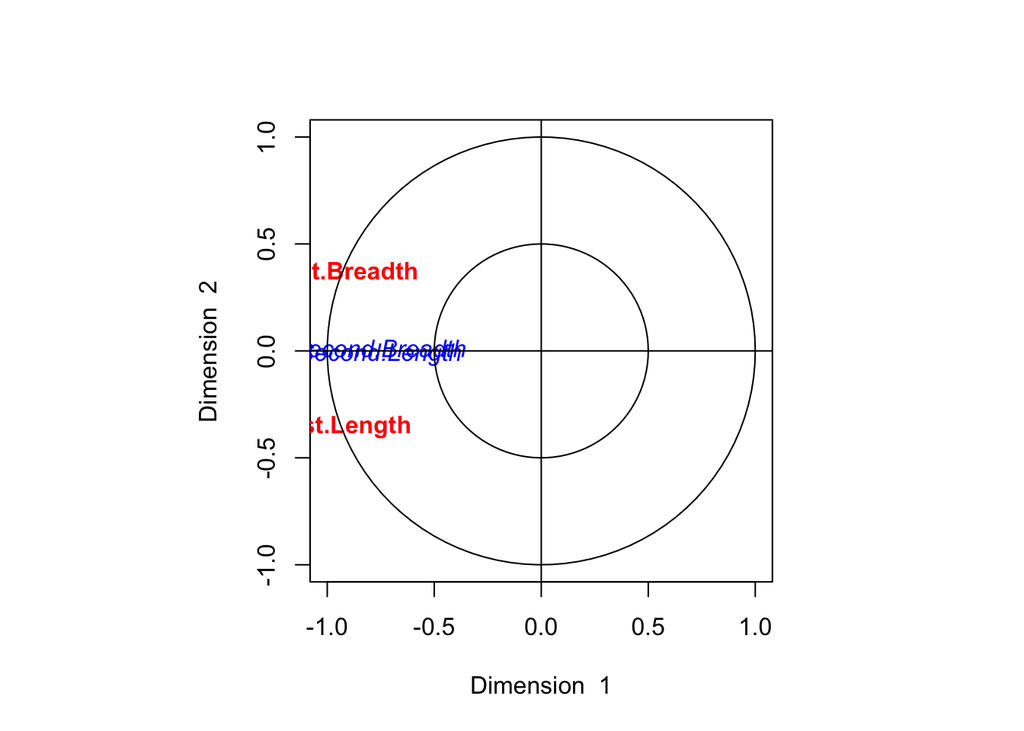

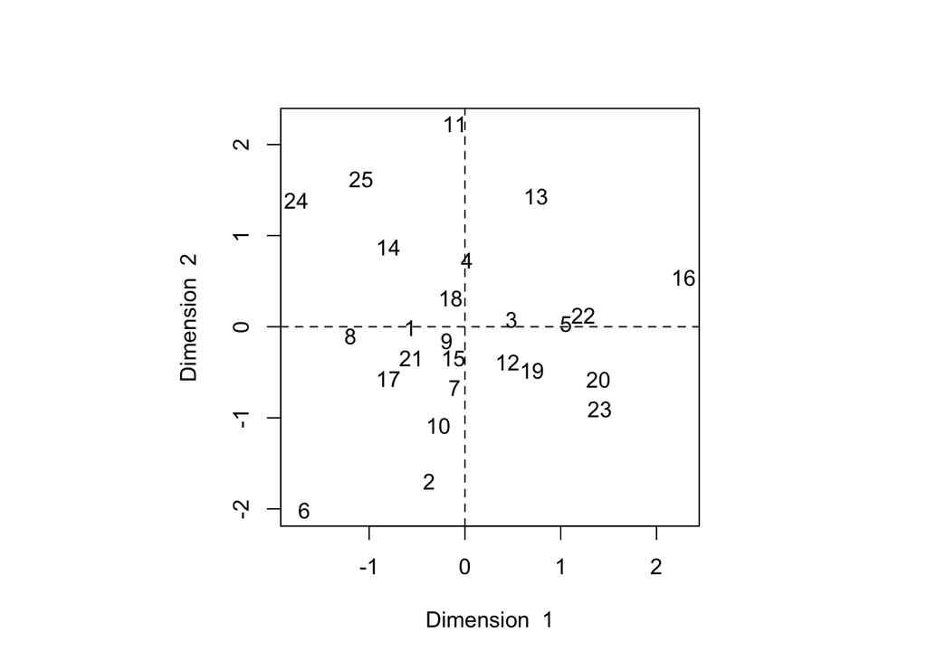